# Taller 5: Forecasting

### Construya un modelo para el cual toda predicción sea la media de los datos.

```python
# Modelo de prediccion basado en la media de los datos
modeloMean = df['Bricks'].mean()
# Crear serie de predicciones
df['Prediction_mean'] = modeloMean
df['Prediction_mean'].head()
```

```
Quarter
1956-01-01    408.201835
1956-04-01    408.201835
1956-07-01    408.201835
1956-10-01    408.201835
1957-01-01    408.201835
Name: Prediction_mean, dtype: float64
```

```python
# Calcular MSE Y R²
mse = mean_squared_error(df['Bricks'], df['Prediction_mean'])
r2 = r2_score(df['Bricks'], df['Prediction_mean'])

print("MSE:", mse)
print("R²:", r2)
```

```
MSE: 8429.0877030553
R²: 0.0
```

- $R²$ Directamente muestra que el modelo no es para nada adecuado
- MSE Directamente es un valor muy alto, lo que corrobora a $R²$

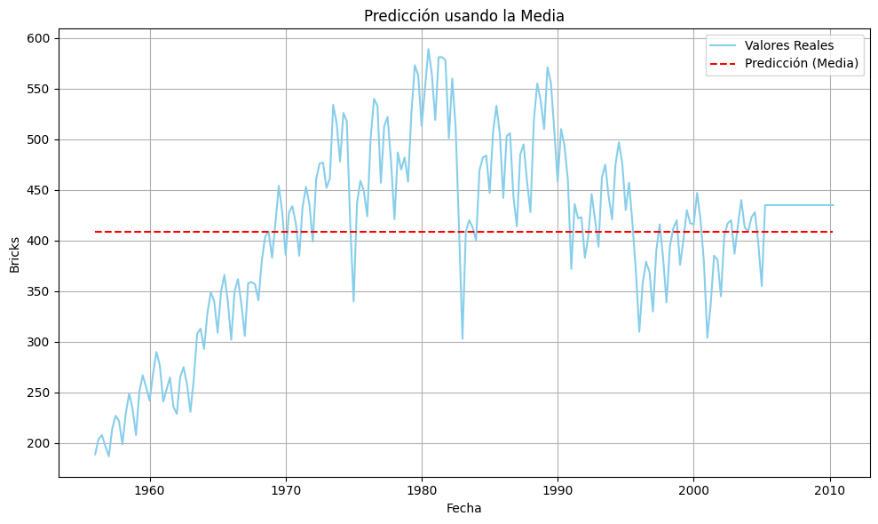

```python
# Grafica valores reales vs predicciones
plt.figure(figsize=(10,6))
plt.plot(df.index, df['Bricks'], label='Valores Reales', color='skyblue')
plt.plot(df.index, df['Prediction_mean'], label='Predicción (Media)', color='red', linestyle='--')
plt.title('Predicción usando la Media')
plt.xlabel('Fecha')
plt.ylabel('Bricks')
plt.legend()
plt.tight_layout()
plt.grid(True)
plt.show()
```

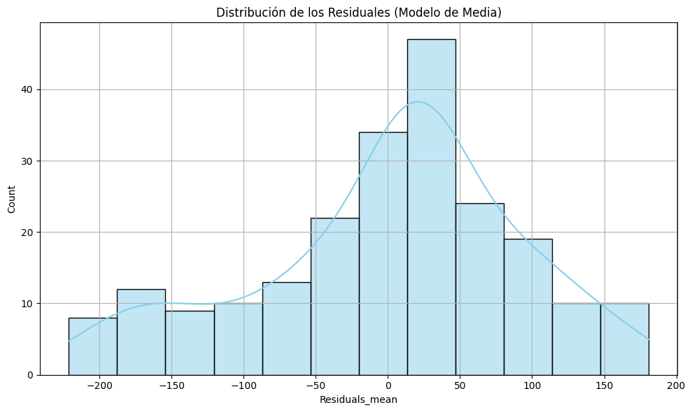

```python
# Calcular residuales
df['Residuals_mean'] = df['Bricks'] - df['Prediction_mean']

# Graficar la distribución de los residuales
plt.figure(figsize=(10,6))
sns.histplot(df['Residuals_mean'], kde=True, color='skyblue')
plt.title('Distribución de los Residuales (Modelo de Media)')
plt.tight_layout()
plt.grid(True)
plt.show()
```

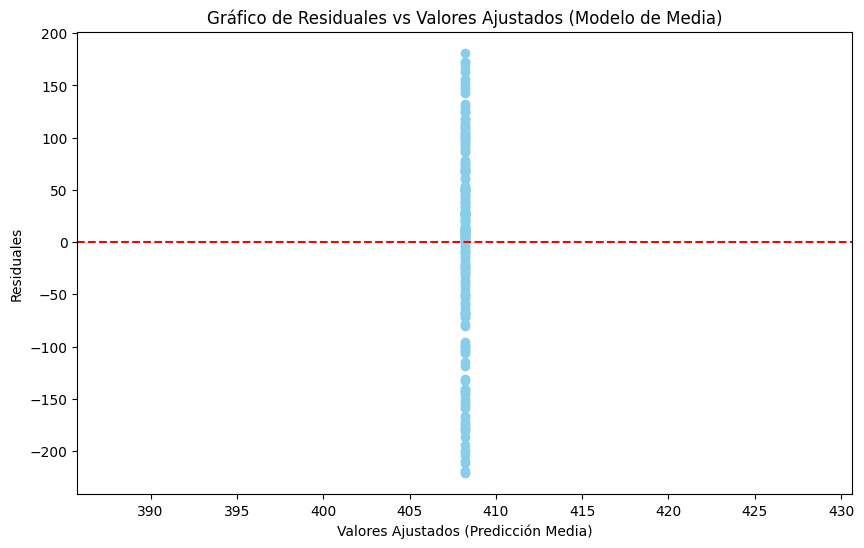

```python
# Graficas de diagnostico (Residuales vs Valores Ajustados)

plt.figure(figsize=(10,6))
plt.scatter(df['Prediction_mean'], df['Residuals_mean'], color='skyblue')
plt.axhline(y=0, color='red', linestyle='--')
plt.title('Gráfico de Residuales vs Valores Ajustados (Modelo de Media)')
plt.xlabel('Valores Ajustados (Predicción Media)')
plt.ylabel('Residuales')
plt.show()
```

- Los puntos muestran un patron y no estan distribuidos aleatoriamente a lo largo de $y$ = 0

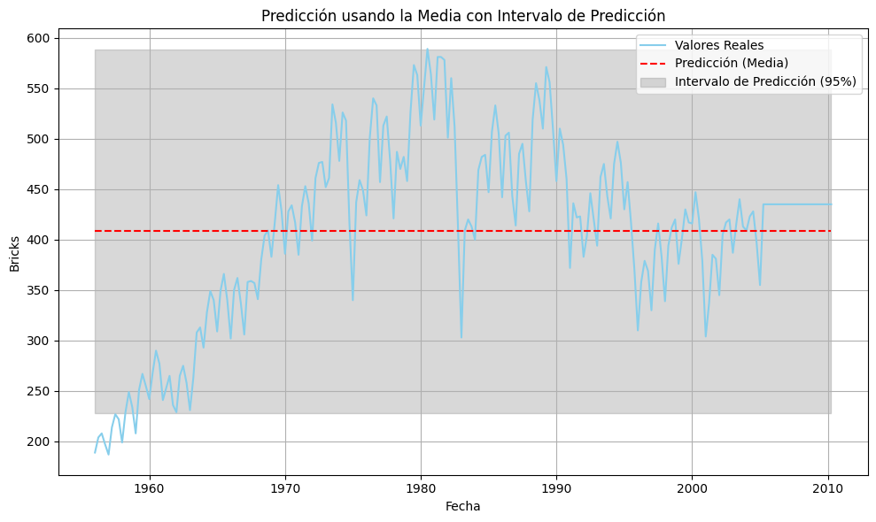

```python
# Intervalo de prediccion
std_residuals = np.std(df['Residuals_mean'])
df['Lower_bound'] = modeloMean - 1.96 * std_residuals
df['Upper_bound'] = modeloMean + 1.96 * std_residuals

# Graficar valores reales, predicciones e intervalo de prediccion
plt.figure(figsize=(10,6))
plt.plot(df.index, df['Bricks'], label='Valores Reales', color='skyblue')
plt.plot(df.index, df['Prediction_mean'], label='Predicción (Media)', color='red', linestyle='--')
plt.fill_between(df.index, df['Lower_bound'], df['Upper_bound'], color='gray', alpha=0.3, label='Intervalo de Predicción (95%)')
plt.title('Predicción usando la Media con Intervalo de Predicción')
plt.xlabel('Fecha')
plt.ylabel('Bricks')
plt.legend()
plt.tight_layout()
plt.grid(True)
plt.show()
```

### Construya un modelo para el cual toda predicción sea el punto inmediatamente anterior

```python
# Modelo de prediccion punto inmediatamente anterior
df['Prediction_previous'] = df['Bricks'].shift(1)

# Eliminar la primer prediccion puesto que sera NaN
df = df.dropna(subset=['Prediction_previous'])
```

```python
# Calcular MSE Y R²
mse = mean_squared_error(df['Bricks'], df['Prediction_previous'])
r2 = r2_score(df['Bricks'], df['Prediction_previous'])

print("MSE:", mse)
print("R²:", r2)
```

```
MSE: 1466.921658986175
R²: 0.8220939513162079
```

- $R²$ Tiene un valor bastante cercano a 1, buen ajuste de los datos
- MSE no es un valor tan grande, el modelo puede haberse ajustado bien a los datos

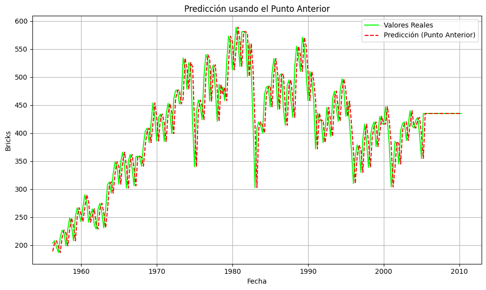

```python
# Graficar valores reales vs predicciones
plt.figure(figsize=(10,6))
plt.plot(df.index, df['Bricks'], label='Valores Reales', color='lime')
plt.plot(df.index, df['Prediction_previous'], label='Predicción (Punto Anterior)', color='red', linestyle='--')
plt.title('Predicción usando el Punto Anterior')
plt.xlabel('Fecha')
plt.ylabel('Bricks')
plt.legend()
plt.grid(True)
plt.tight_layout()
plt.show()
```

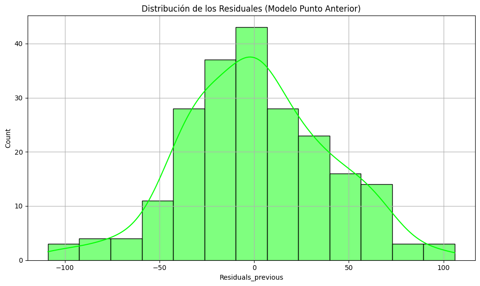

```python
# Calcular residuales
df['Residuals_previous'] = df['Bricks'] - df['Prediction_previous']

# Graficar la distribucion de los residuales
plt.figure(figsize=(10,6))
sns.histplot(df['Residuals_previous'], kde=True, color='lime')
plt.title('Distribución de los Residuales (Modelo Punto Anterior)')
plt.grid(True)
plt.tight_layout()
plt.show()
```

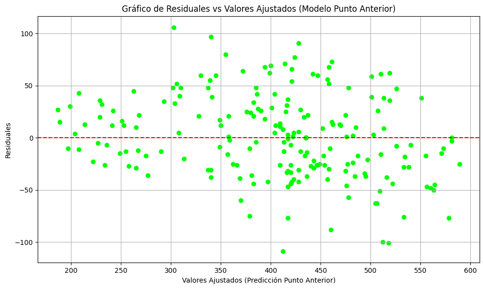

```python
# Grafica de diagnostico (Residuales vs Valores Ajustados)
plt.figure(figsize=(10,6))
plt.scatter(df['Prediction_previous'], df['Residuals_previous'], color='lime')
plt.axhline(y=0, color='red', linestyle='--')
plt.title('Gráfico de Residuales vs Valores Ajustados (Modelo Punto Anterior)')
plt.xlabel('Valores Ajustados (Predicción Punto Anterior)')
plt.ylabel('Residuales')
plt.grid(True)
plt.tight_layout()
plt.show()
```

- Presenta homocedasticidad

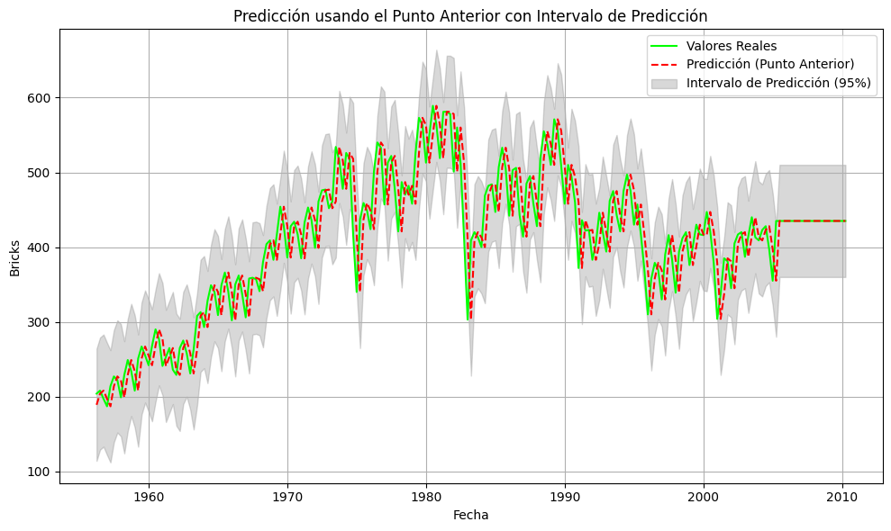

```python
# Intervalo de prediccion
std_residuals_previous = np.std(df['Residuals_previous'])
df['Lower_bound_previous'] = df['Prediction_previous'] - 1.96 * std_residuals_previous
df['Upper_bound_previous'] = df['Prediction_previous'] + 1.96 * std_residuals_previous

# Visualizar los valores reales, predicciones y el intervalo de predicción
plt.figure(figsize=(10,6))
plt.plot(df.index, df['Bricks'], label='Valores Reales', color='lime')
plt.plot(df.index, df['Prediction_previous'], label='Predicción (Punto Anterior)', color='red', linestyle='--')
plt.fill_between(df.index, df['Lower_bound_previous'], df['Upper_bound_previous'], color='gray', alpha=0.3, label='Intervalo de Predicción (95%)')
plt.title('Predicción usando el Punto Anterior con Intervalo de Predicción')
plt.xlabel('Fecha')
plt.ylabel('Bricks')
plt.grid(True)
plt.tight_layout()
plt.legend()
plt.show()
```

### Determine la estacionalidad de la serie y construya un modelo para el cual toda predicción sea él valor de la serie en la estación inmediatamente anterior.

```python
# Modelo estacional
period = 4 # 4 Quartiles
df['Prediction_seasonal'] = df['Bricks'].shift(period)

# Ignorar las primeras 'period' filas que no tienen un valor anterior para predecir
df = df.dropna(subset=['Prediction_seasonal'])
```

```python
# Calcular MSE y R²
mse = mean_squared_error(df['Bricks'], df['Prediction_seasonal'])
r2 = r2_score(df['Bricks'], df['Prediction_seasonal'])

print("MSE:", mse)
print("R²:", r2)
```

```
MSE: 2164.525821596244
R²: 0.7134487079244535
```

- $R²$ Tiene un valor cercano a 1, un buen ajuste de los datos
- MSE no es un valor tan grande, el modelo puede haberse ajustado bien a los datos

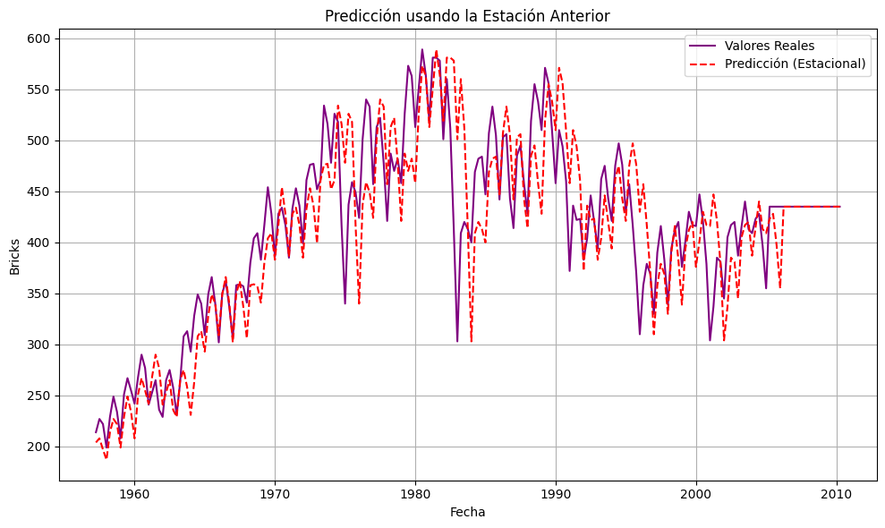

```python
# Grafica de valores reales vs predicciones
plt.figure(figsize=(10,6))
plt.plot(df.index, df['Bricks'], label='Valores Reales', color='purple')
plt.plot(df.index, df['Prediction_seasonal'], label='Predicción (Estacional)', color='red', linestyle='--')
plt.title('Predicción usando la Estación Anterior')
plt.xlabel('Fecha')
plt.ylabel('Bricks')
plt.grid(True)
plt.tight_layout()
plt.legend()
plt.show()
```

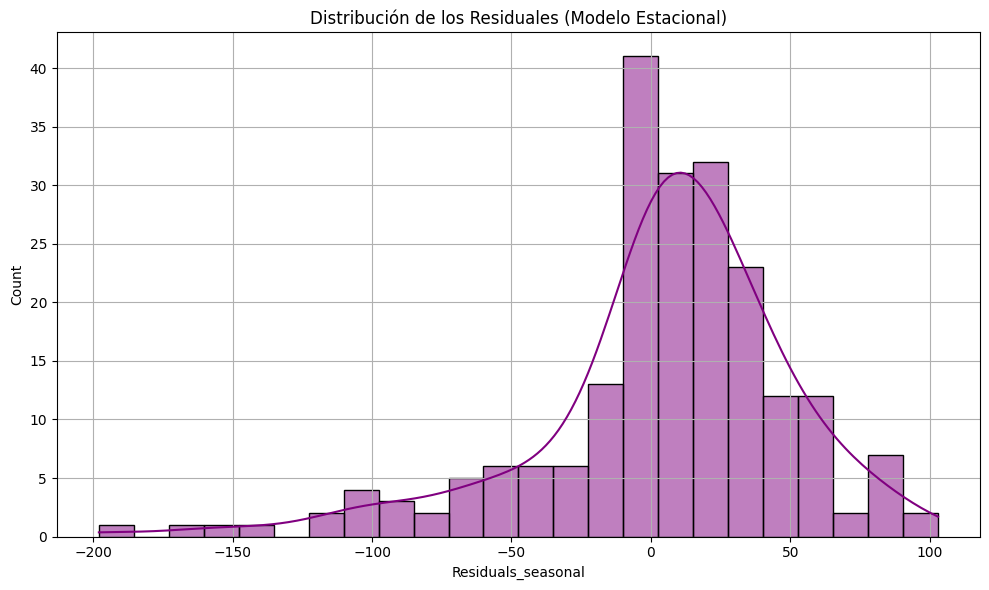

```python
# Calcular los residuales
df['Residuals_seasonal'] = df['Bricks'] - df['Prediction_seasonal']

# Visualizar la distribucion de los residuales
plt.figure(figsize=(10,6))
sns.histplot(df['Residuals_seasonal'], kde=True, color='purple')
plt.title('Distribución de los Residuales (Modelo Estacional)')
plt.grid(True)
plt.tight_layout()
plt.show()
```

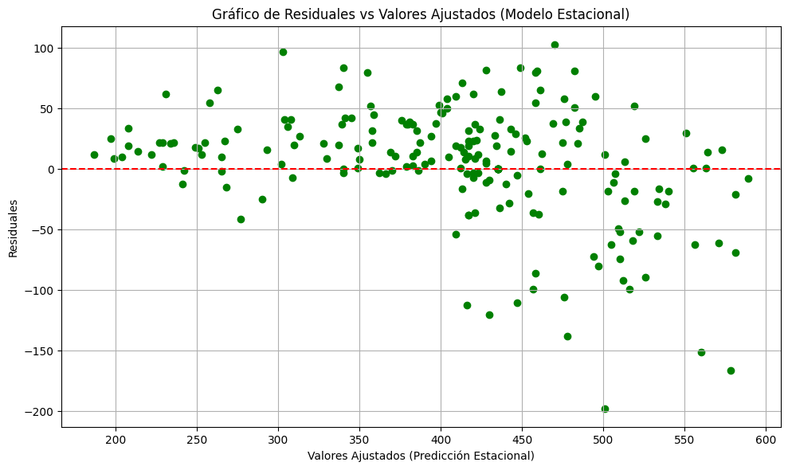

```python
# Grafico de diagnóstico (Residuales vs Valores Ajustados)

plt.figure(figsize=(10,6))
plt.scatter(df['Prediction_seasonal'], df['Residuals_seasonal'], color='green')
plt.axhline(y=0, color='red', linestyle='--')
plt.title('Gráfico de Residuales vs Valores Ajustados (Modelo Estacional)')
plt.xlabel('Valores Ajustados (Predicción Estacional)')
plt.ylabel('Residuales')
plt.grid(True)
plt.tight_layout()
plt.show()
```

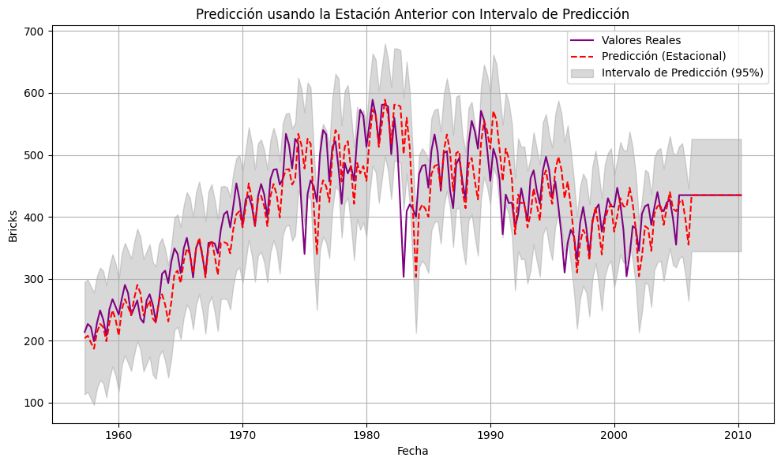

```python
std_residuals_seasonal = np.std(df['Residuals_seasonal'])
df['Lower_bound_seasonal'] = df['Prediction_seasonal'] - 1.96 * std_residuals_seasonal
df['Upper_bound_seasonal'] = df['Prediction_seasonal'] + 1.96 * std_residuals_seasonal

# Visualizar los valores reales, predicciones y el intervalo de predicción
plt.figure(figsize=(10,6))
plt.plot(df.index, df['Bricks'], label='Valores Reales', color='purple')
plt.plot(df.index, df['Prediction_seasonal'], label='Predicción (Estacional)', color='red', linestyle='--')
plt.fill_between(df.index, df['Lower_bound_seasonal'], df['Upper_bound_seasonal'], color='gray', alpha=0.3, label='Intervalo de Predicción (95%)')
plt.title('Predicción usando la Estación Anterior con Intervalo de Predicción')
plt.xlabel('Fecha')
plt.ylabel('Bricks')
plt.grid(True)
plt.tight_layout()
plt.legend()
plt.show()
```

### Ajuste un modelo de regresión lineal

```python
# Modelo de regresion lineal

# Como las series de tiempo se basan en el tiempo, creamos una variable "tiempo" (X) para la regresión
df['Time'] = np.arange(len(df))

X = df[['Time']]  # Variable independiente (Tiempo)
y = df['Bricks']  # Variable dependiente (Valores de la serie Bricks)
```

```python
# Crear y ajustar modelo de regresion lineal
model = LinearRegression()
model.fit(X, y)

# Generar las predicciones
df['Prediction_linear'] = model.predict(X)
```

```python
# Calcular MSE Y R²

mse = mean_squared_error(df['Bricks'], df['Prediction_linear'])
r2 = r2_score(df['Bricks'], df['Prediction_linear'])

print("MSE:", mse)
print("R²:", r2)
```

```
MSE: 6288.539270157361
R²: 0.1674901564341158
```

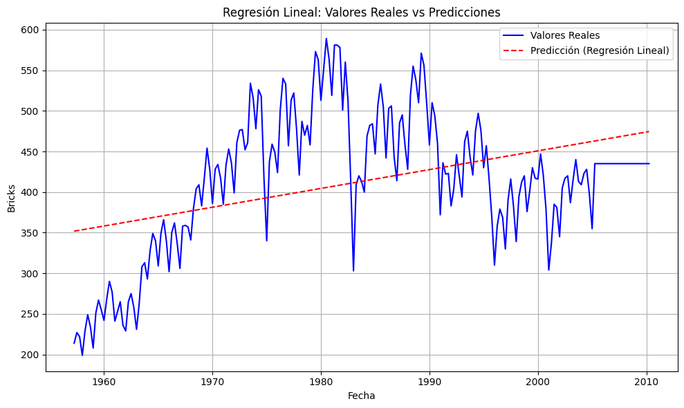

```python
# Graficar valores reales vs predicciones
plt.figure(figsize=(10,6))
plt.plot(df.index, df['Bricks'], label='Valores Reales', color='blue')
plt.plot(df.index, df['Prediction_linear'], label='Predicción (Regresión Lineal)', color='red', linestyle='--')
plt.title('Regresión Lineal: Valores Reales vs Predicciones')
plt.xlabel('Fecha')
plt.ylabel('Bricks')
plt.grid(True)
plt.tight_layout()
plt.legend()
plt.show()
```

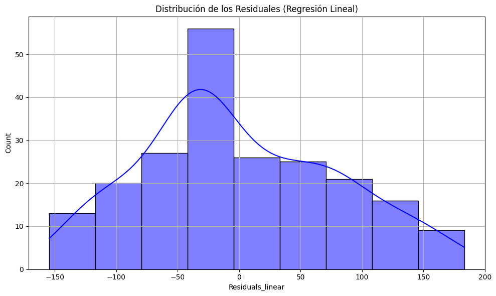

```python
# Calcular residuales
df['Residuals_linear'] = df['Bricks'] - df['Prediction_linear']

# Visualizar la distribucion de los residuales
plt.figure(figsize=(10,6))
sns.histplot(df['Residuals_linear'], kde=True, color='blue')
plt.title('Distribución de los Residuales (Regresión Lineal)')
plt.grid(True)
plt.tight_layout()
plt.show()
```

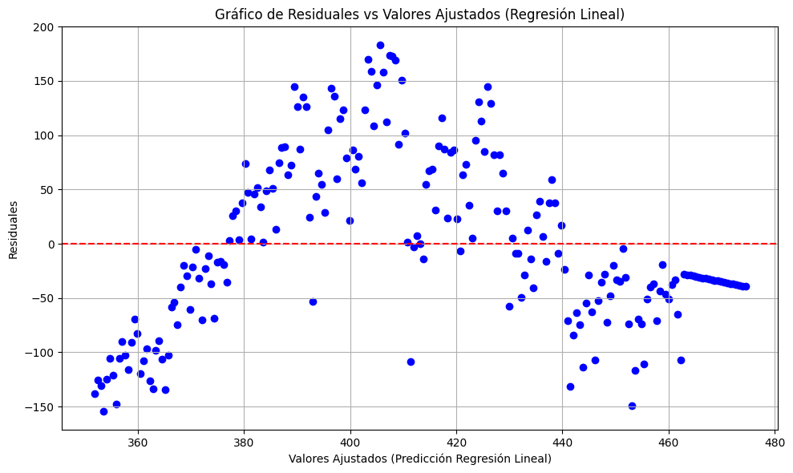

```python
# Graficp de diagnóstico (Residuales vs Valores Ajustados)

plt.figure(figsize=(10,6))
plt.scatter(df['Prediction_linear'], df['Residuals_linear'], color='blue')
plt.axhline(y=0, color='red', linestyle='--')
plt.title('Gráfico de Residuales vs Valores Ajustados (Regresión Lineal)')
plt.xlabel('Valores Ajustados (Predicción Regresión Lineal)')
plt.ylabel('Residuales')
plt.grid(True)
plt.tight_layout()
plt.show()
```

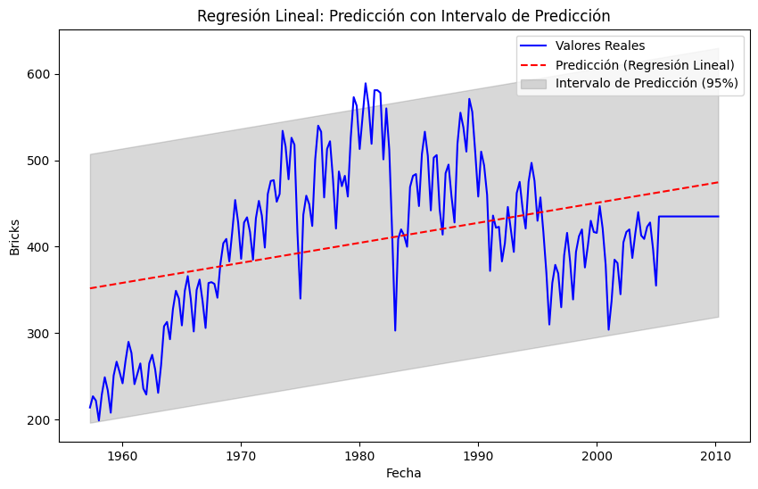

```python
# Intervalo de prediccion
std_residuals_linear = np.std(df['Residuals_linear'])
df['Lower_bound_linear'] = df['Prediction_linear'] - 1.96 * std_residuals_linear
df['Upper_bound_linear'] = df['Prediction_linear'] + 1.96 * std_residuals_linear

# Visualizar los valores reales, predicciones y el intervalo de predicción
plt.figure(figsize=(10,6))
plt.plot(df.index, df['Bricks'], label='Valores Reales', color='blue')
plt.plot(df.index, df['Prediction_linear'], label='Predicción (Regresión Lineal)', color='red', linestyle='--')
plt.fill_between(df.index, df['Lower_bound_linear'], df['Upper_bound_linear'], color='gray', alpha=0.3, label='Intervalo de Predicción (95%)')
plt.title('Regresión Lineal: Predicción con Intervalo de Predicción')
plt.xlabel('Fecha')
plt.ylabel('Bricks')
plt.legend()
plt.show()
```

### Ajuste un modelo de regresión polinomial. Determine el grado del polinomio que a su criterio mejor se ajusta a los datos.

```python
from sklearn.preprocessing import PolynomialFeatures
from sklearn.pipeline import make_pipeline
# Modelo regresion polinomial

degrees = [1, 2, 3, 4, 5] # Grado polinomio
mse_results = []

for degree in degrees:
    # Crear un pipeline para el modelo polinomial
    model_poly = make_pipeline(PolynomialFeatures(degree), LinearRegression())
    model_poly.fit(X, y)

    # Hacer las predicciones
    df[f'Prediction_poly_{degree}'] = model_poly.predict(X)

    # Calcular el MSE y R²
    mse_poly = mean_squared_error(df['Bricks'], df[f'Prediction_poly_{degree}'])
    mse_results.append((degree, mse_poly))



best_degree = min(mse_results, key=lambda x: x[1])[0]
print(f"El mejor grado para el modelo polinomial es: {best_degree}")
```

```
El mejor grado para el modelo polinomial es: 5
```

```python
# Ajustar el modelo segun el mejor grado

best_model_poly = make_pipeline(PolynomialFeatures(best_degree), LinearRegression())
best_model_poly.fit(X, y)
df['Prediction_poly_best'] = best_model_poly.predict(X)

# Evaluación del mejor modelo
mse_best_poly = mean_squared_error(df['Bricks'], df['Prediction_poly_best'])
r2_best_poly = r2_score(df['Bricks'], df['Prediction_poly_best'])

print(f"MSE (Regresión Polinomial Grado {best_degree}): {mse_best_poly}")
print(f"R² (Regresión Polinomial Grado {best_degree}): {r2_best_poly}")
```

```
MSE (Regresión Polinomial Grado 5): 1730.1470859584906
R² (Regresión Polinomial Grado 5): 0.7709540454469913
```

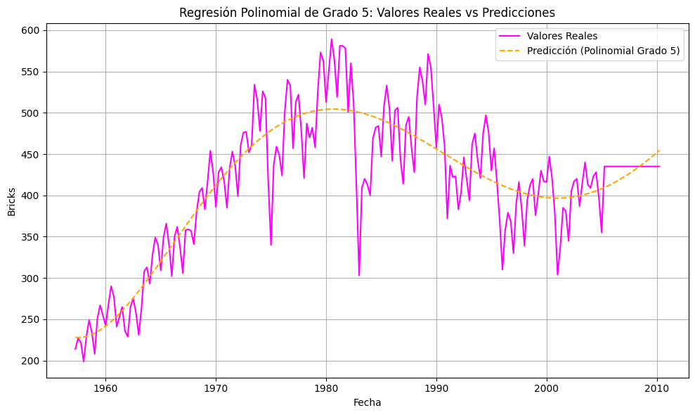

```python
# Graficar valores reales vs predicciones
plt.figure(figsize=(10,6))
plt.plot(df.index, df['Bricks'], label='Valores Reales', color='fuchsia')
plt.plot(df.index, df['Prediction_poly_best'], label=f'Predicción (Polinomial Grado {best_degree})', color='orange', linestyle='--')
plt.title(f'Regresión Polinomial de Grado {best_degree}: Valores Reales vs Predicciones')
plt.xlabel('Fecha')
plt.ylabel('Bricks')
plt.legend()
plt.grid(True)
plt.tight_layout()
plt.show()
```

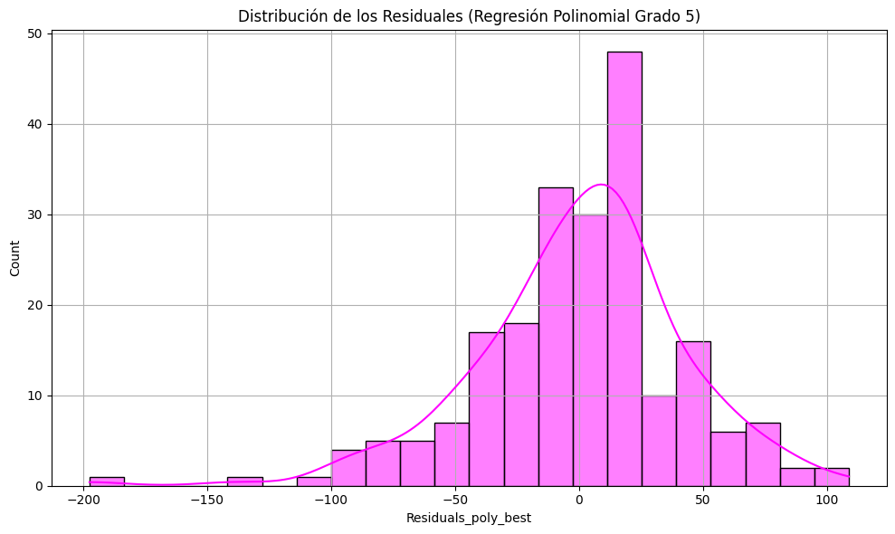

```python
# Calcular los residuales
df['Residuals_poly_best'] = df['Bricks'] - df['Prediction_poly_best']

# Visualizar la distribución de los residuales
plt.figure(figsize=(10,6))
sns.histplot(df['Residuals_poly_best'], kde=True, color='fuchsia')
plt.title(f'Distribución de los Residuales (Regresión Polinomial Grado {best_degree})')
plt.grid(True)
plt.tight_layout()
plt.show()
```

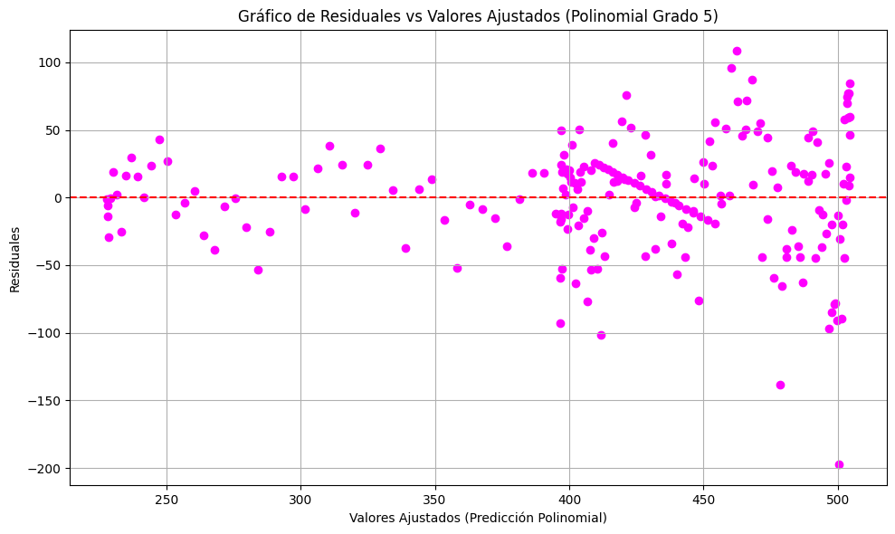

```python
# Grafico de diagnostico (Residuales vs Valores Ajustados)

plt.figure(figsize=(10,6))
plt.scatter(df['Prediction_poly_best'], df['Residuals_poly_best'], color='fuchsia')
plt.axhline(y=0, color='red', linestyle='--')
plt.title(f'Gráfico de Residuales vs Valores Ajustados (Polinomial Grado {best_degree})')
plt.xlabel('Valores Ajustados (Predicción Polinomial)')
plt.ylabel('Residuales')
plt.grid(True)
plt.tight_layout()
plt.show()
```

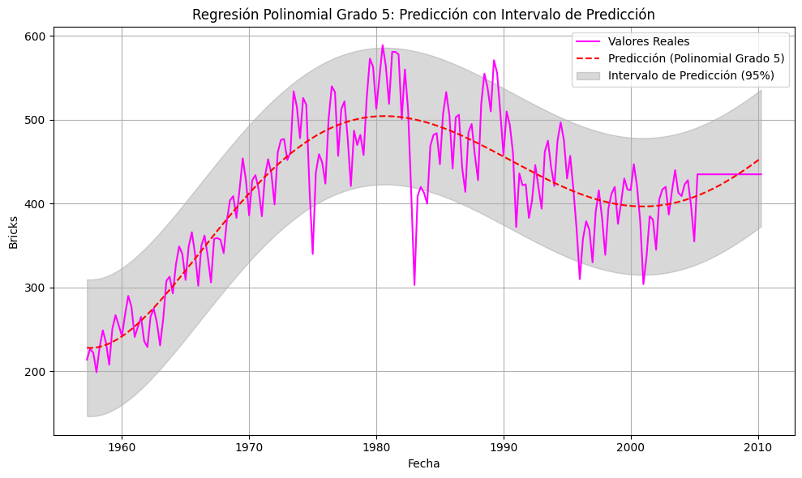

```python
# Intervalo de predicción
std_residuals_poly = np.std(df['Residuals_poly_best'])
df['Lower_bound_poly'] = df['Prediction_poly_best'] - 1.96 * std_residuals_poly
df['Upper_bound_poly'] = df['Prediction_poly_best'] + 1.96 * std_residuals_poly

# Visualizar los valores reales, predicciones y el intervalo de predicción
plt.figure(figsize=(10,6))
plt.plot(df.index, df['Bricks'], label='Valores Reales', color='fuchsia')
plt.plot(df.index, df['Prediction_poly_best'], label=f'Predicción (Polinomial Grado {best_degree})', color='red', linestyle='--')
plt.fill_between(df.index, df['Lower_bound_poly'], df['Upper_bound_poly'], color='gray', alpha=0.3, label='Intervalo de Predicción (95%)')
plt.title(f'Regresión Polinomial Grado {best_degree}: Predicción con Intervalo de Predicción')
plt.xlabel('Fecha')
plt.ylabel('Bricks')
plt.grid(True)
plt.tight_layout()
plt.legend()
plt.show()
```

# 14. A partir de los resultados del punto anterior, seleccioné según su criterio cuál sería el mejor modelo. Tenga en cuenta los valores de $MSE$, el diagnóstico de residuales y el valor de $R²$

- Definitivamente el mejor modelo seria el modelo para el cual toda predicción sea el punto inmediatamente anterior

[figure not shown]